# Will they pay? —Machine Learning in predicting credit card default

## Introduction

Imagine yourself as a CEO of a bank, and you want to devise a way to make wise decisions about clients’ credit limits. Why? Well increasing credit limits for reliable clients increases trust, and preventing defaults protects the bank.

To help you make decisions, I build a model to predict if clients will default next month.

## Outline

- The dataset
- Building models
- Findings
- Caveats of the findings

## The dataset

**Exploaratory data analysis (EDA)**: by examining each column(known as features) in the dataset, a general knowledge of the features is gained. Below are some findings:

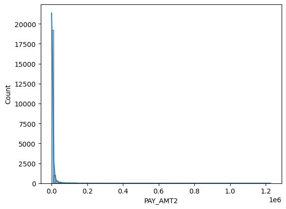

```python
from IPython.display import Image

Image("img/eda-outlier.png")
```

One thing can be noticed from EDA is outliers. Notice the X-axis in the graph above. A weird proportion on the axis suggest the existence of outlier. I removed outliers accordingly as it then prevents the model from learning biases in extreme values.

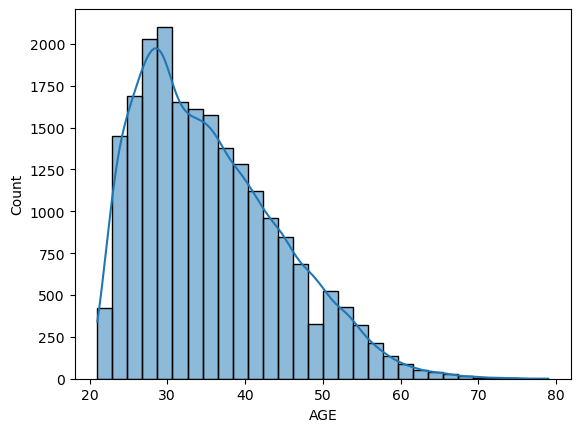

```python
Image("img/eda-age.png")
```

The bar graph above shows the age distribution in the dataset. More clients in this dataset is around 30. So the model trained with this data might perform better on similar age groups.

**Feature Engineering**: This step involves creating new features to aid prediction. After testing for the importance of features, the new created column is of good importance:

*DEBT_REPAYMENT_RATIO*: ratio between the amount offered by the bank and the amount paid back by client.

## Building Models

Two types of models were examined: gradient boosted models and non-gradient boosted models.

**An analogy**: A way to think about these gradient boost models is like a tutor giving you feedback after each quiz, instead of giving you all the marks at once. The model can check the mistakes they made on previous “quiz” and avoid similar mistakes in the future. In contrast, non-gradient boosted models is more like doing the same quiz multiple times and taking the best score from it.

**Further adjustments**: To bring out the best performance in the models, some specific values(known as hyperparameters) need to be set. So after testing the models on a list of different hyperparameters, we are able to pick one giving highest accuracy. For example, in a model named HGB, - max_depth=8 - min_samples_leaf=5

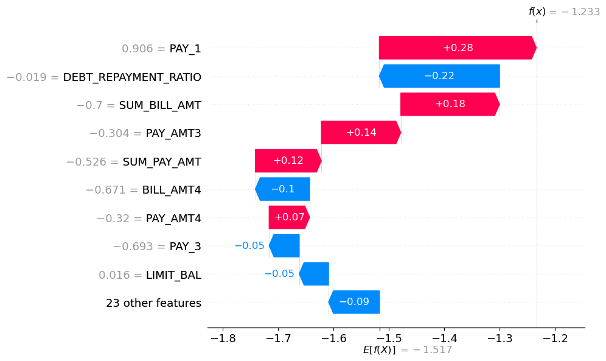

```python
Image("img/output.png")
```

Finally we can see how each feature contribute to making the prediction. From the graph above, like mentioned, DEBT_REPAYMENT_RATIO is useful and pulls the prediction to the negative. In our case, 0 means not default and 1 means default. So increase in the ratio decrease the possibility of default. Other features can be interpreted in similar ways.

## Findings

Multiple models were tested and the one with best result is from sklearn’s HisGB(Histogram gradient boost), with accuracy of 0.82. Note that LightGBM(Light Gradient Boost) also work well with a slightly lower accuracy of 0.81.

## Caveats of the findings

**More feature engineering needed**: the feature importance vary a lot between observations. For example, the case below:

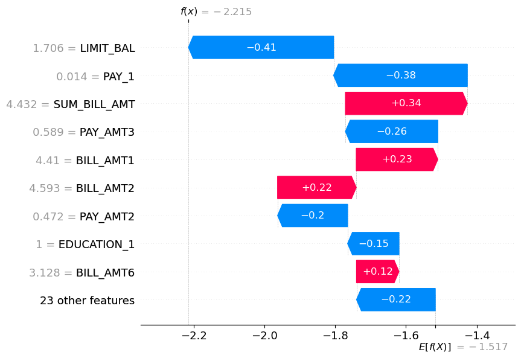

```python
Image("img/output2.png")
```

DEBT_REPAYMENT_RATIO does not affect the prediction as much as previously seen. While PAY_1 still remain as a strong predictor. Creating better features might make the predictions better. Also, the original dataset has some ambiguity, some features are not clearly explained on Kaggle, which makes it hard to interpret.

**Removing outliers by assumption:** In EDA, after spotting the outliers I chose to remove them. However, in real life, there is going to be extremely wealthy people as bank client. Removing those data might result in a decreased performance of the model in real world. Maybe a separate model could be built for the outliers instead of dropping them.